# Doctor’s Helper

The following report contains comprehensive analysis of the medical data gathered in the local hospital, which concern the health and environmental factors of its patients. Additionally, it introduces the machine learning model which aims to identify patients' attributes which make them more likely to have a disease. The model can be important tool in helping doctors to detect patients at higher risk of getting ill faster and, thanks to that, start the treatment in the early stage of a disease.

## 1. Data Exploration

The following section shows the contents of the records in analysed dataset and summarizes the main characteristics of the patients. The dataframe consists of 13 attributes and contains information about 768 female patients - their blood chemistry, blood pressure, number of pregnancies, skin thickness, BMI, genetic predispositions to disease, their age, state where they live and its air condidtion. It is also known which patient is ill.

```python
# import required modules
import pandas as pd
import numpy as np
from scipy import stats
import warnings

warnings.filterwarnings('ignore')
```

```python
seed = 61
np.random.seed(61)
```

```python
df = pd.read_csv('good_doctor_data.csv')
df = df.iloc[df.index[~df.isnull().all(1)]]
df.head()
```

|  | Unique_ID | # Pregnancies | Blood Chemestry~I | Blood Chemisty~II | Blood Chemisty~III | Blood Pressure | Skin Thickness | BMI | Genetic Predisposition Factor | Age | Air Qual'ty Index | $tate | Outcome |
| --- | --- | --- | --- | --- | --- | --- | --- | --- | --- | --- | --- | --- | --- |
| 0 | 5642118.0 | 1.0 | 0.0 | 23.0 | 10.0 | 74.0 | 20.0 | 27.7 | 0.299 | 21.0 | 38.0 | CA | 0.0 |
| 2 | 5642119.0 | 1.0 | 0.0 | 0.0 | 61.0 | 68.0 | 35.0 | 32.0 | 0.389 | 22.0 | 10.0 | CA | 0.0 |
| 4 | 5642120.0 | 1.0 | 0.0 | 0.0 | 172.0 | 48.0 | 20.0 | 24.7 | 0.140 | 22.0 | 77.0 | CA | 0.0 |
| 6 | 5642121.0 | 5.0 | 44.0 | 0.0 | 207.0 | 62.0 | 0.0 | 25.0 | 0.587 | 36.0 | 40.0 | OR | 0.0 |
| 8 | 5642122.0 | 2.0 | 56.0 | 45.0 | 150.0 | 56.0 | 28.0 | 24.2 | 0.332 | 22.0 | 70.0 | CT | 0.0 |

```python
df.shape
```

```
(3840, 13)
```

```python
orig_colnames = df.columns
cols = ['id', 'pregnancies', 'blood_1', 'blood_2', 'blood_3',
        'blood_pressure', 'skin_thickness', 'bmi', 'gen_pred_factor',
        'age', 'air_quality', 'state', 'outcome']
pretty_cols = ['Patient ID', '# Pregnancies', 'Blood Chem. I', 'Blood Chem. II', 'Blood Chem. III',
               'Blood Pressure', 'Skin Thickness', 'BMI', 'Genetic Pred. Factor',
               'Age', 'Air Quality Index', 'State', 'Outcome']
cols_dict = {cols[i]: pretty_cols[i] for i in range(len(cols))}
df.columns = cols
```

```python
df.nunique()
```

```
id                 768
pregnancies         17
blood_1            136
blood_2            186
blood_3            351
blood_pressure      47
skin_thickness      51
bmi                248
gen_pred_factor    517
age                 53
air_quality        100
state               49
outcome              2
dtype: int64
```

```python
df.groupby('id').nunique().sum()
```

```
pregnancies         768
blood_1             763
blood_2             766
blood_3            3821
blood_pressure      768
skin_thickness      767
bmi                 768
gen_pred_factor     768
age                 768
air_quality         762
state               768
outcome             768
dtype: int64
```

One can notice that each patient has 5 measurements for Blood Chemistry III, each in a separate row. For the analysis purpose, all 5 measurements for each patient were moved to the single row and labeled with number from 1 to 5.

```python
smpls_per_patient = df.groupby('id')['blood_3'].count().unique()[0]
smpls_per_patient
```

```
5
```

```python
# sort values by id to label Blood Chemistry III measurements correctly
df.sort_values('id', inplace=True)
df.reset_index(drop=True, inplace=True)

# for each patient assign label indicating Blood Chemistry III measurement number
measure_no = 'blood_3_m_1, blood_3_m_2, blood_3_m_3, blood_3_m_4, blood_3_m_5'.split(', ')
df['measure_no'] = measure_no * df['id'].nunique()

original_df = df.copy()

# select columns which are meant to be indeces in the pivot table
index_col = list(df.columns)
index_col.remove('measure_no')
index_col.remove('blood_3')

# pivot table to move all the five measurement
# of Blood Chemistry III to the same row
df = df.fillna('dummy').pivot_table(index=index_col, columns='measure_no', values='blood_3')
df.reset_index(inplace=True)
df = df.replace('dummy', np.NaN)
df.head()
```

| measure_no | id | pregnancies | blood_1 | blood_2 | blood_pressure | skin_thickness | bmi | gen_pred_factor | age | air_quality | state | outcome | blood_3_m_1 | blood_3_m_2 | blood_3_m_3 | blood_3_m_4 | blood_3_m_5 |
| --- | --- | --- | --- | --- | --- | --- | --- | --- | --- | --- | --- | --- | --- | --- | --- | --- | --- |
| 0 | 5642118.0 | 1.0 | 0.0 | 23.0 | 74.0 | 20.0 | 27.7 | 0.299 | 21.0 | 38.0 | CA | 0.0 | 10.0 | 45.0 | 333.0 | 228.0 | 22.0 |
| 1 | 5642119.0 | 1.0 | 0.0 | 0.0 | 68.0 | 35.0 | 32.0 | 0.389 | 22.0 | 10.0 | CA | 0.0 | 342.0 | 146.0 | 338.0 | 61.0 | 193.0 |
| 2 | 5642120.0 | 1.0 | 0.0 | 0.0 | 48.0 | 20.0 | 24.7 | 0.140 | 22.0 | 77.0 | CA | 0.0 | 229.0 | 172.0 | 96.0 | 115.0 | 56.0 |
| 3 | 5642121.0 | 5.0 | 44.0 | 0.0 | 62.0 | 0.0 | 25.0 | 0.587 | 36.0 | 40.0 | OR | 0.0 | 64.0 | 245.0 | 86.0 | 207.0 | 66.0 |
| 4 | 5642122.0 | 2.0 | 56.0 | 45.0 | 56.0 | 28.0 | 24.2 | 0.332 | 22.0 | 70.0 | CT | 0.0 | 286.0 | 33.0 | 313.0 | 150.0 | 114.0 |

```python
df.shape
```

```
(768, 17)
```

```python
# print descriptive statistics of data
num_cols = ['pregnancies', 'blood_1', 'blood_2', 'blood_pressure',
           'skin_thickness', 'bmi', 'gen_pred_factor', 'age', 'air_quality'] + measure_no
round(df[num_cols].describe().T, 3)
```

| measure_no | count | mean | std | min | 25% | 50% | 75% | max |
| --- | --- | --- | --- | --- | --- | --- | --- | --- |
| pregnancies | 768.0 | 3.845 | 3.370 | 0.000 | 1.000 | 3.000 | 6.000 | 17.00 |
| blood_1 | 763.0 | 120.917 | 32.038 | 0.000 | 99.000 | 117.000 | 141.000 | 199.00 |
| blood_2 | 766.0 | 79.820 | 115.335 | 0.000 | 0.000 | 30.500 | 126.750 | 846.00 |
| blood_pressure | 768.0 | 69.105 | 19.356 | 0.000 | 62.000 | 72.000 | 80.000 | 122.00 |
| skin_thickness | 767.0 | 20.542 | 15.962 | 0.000 | 0.000 | 23.000 | 32.000 | 99.00 |
| bmi | 768.0 | 31.993 | 7.884 | 0.000 | 27.300 | 32.000 | 36.600 | 67.10 |
| gen_pred_factor | 768.0 | 0.472 | 0.331 | 0.078 | 0.244 | 0.372 | 0.626 | 2.42 |
| age | 768.0 | 33.513 | 13.730 | 21.000 | 24.000 | 29.000 | 41.000 | 230.00 |
| air_quality | 762.0 | 49.108 | 29.180 | 0.000 | 24.000 | 49.000 | 72.750 | 100.00 |
| blood_3_m_1 | 768.0 | 177.510 | 101.361 | 0.000 | 88.750 | 181.000 | 264.000 | 350.00 |
| blood_3_m_2 | 768.0 | 174.835 | 100.747 | 0.000 | 88.000 | 176.000 | 259.000 | 350.00 |
| blood_3_m_3 | 768.0 | 171.652 | 101.486 | 0.000 | 83.500 | 168.500 | 257.250 | 348.00 |
| blood_3_m_4 | 768.0 | 171.703 | 103.740 | 1.000 | 79.000 | 170.500 | 258.250 | 350.00 |
| blood_3_m_5 | 768.0 | 175.122 | 97.167 | 0.000 | 96.000 | 174.500 | 254.000 | 350.00 |

### Outcome

In the analysed dataset 268 patients (which is about 35% of the gathered observations) were diagnosed as ill.

```python
import matplotlib.pyplot as plt
import seaborn as sns

sns.set_palette("Paired")
sns.set_style("whitegrid")
```

```python
df["outcome"] = df["outcome"].map({1: "Yes", 0: "No"})
```

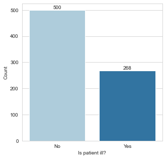

```python
plt.figure(figsize=(5,5))
ax = sns.countplot(x='outcome', data=df, order = df['outcome'].value_counts().index)
ax.set(xlabel="Is patient ill?", ylabel="Count")
ax.bar_label(ax.containers[0])
plt.show()
```

### Pregnancies

The following plot shows the number of pregnancies among analysed patients depending on the diagnosis. It can be noticed that women who have been pregnant more times are more likely to be ill.

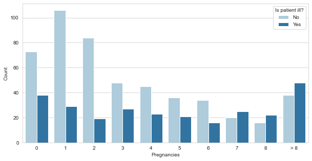

```python
# Label pregnancies greater than given threshold
# To make the countplot looking more clear
def label_greater_than(v, threshold):
    if v > threshold:
        return f"> {threshold}"
    else: return str(int(v))
pregnancy_thr = 8
df['pregnancies_ctg'] = df['pregnancies'].apply(lambda x: str(label_greater_than(x, pregnancy_thr)))
ctgs = [str(x) for x in list(range(0, pregnancy_thr+1))]
ctgs.append(f'> {pregnancy_thr}')
df['pregnancies_ctg'] = pd.Categorical(df['pregnancies_ctg'], categories=ctgs, ordered=True)

fig, ax = plt.subplots(figsize=(10, 5))
sns.countplot(x ='pregnancies_ctg', hue = "outcome", data = df)
ax.set(xlabel='Pregnancies', ylabel='Count')
plt.legend(title='Is patient ill?', loc='upper right', labels=['No', 'Yes'])
df.drop(columns=['pregnancies_ctg'], inplace=True)
plt.show()
```

### Blood Chemistry I, II, III

The following plot shows the frequency of occurrence of each possible value of blood chemistry III for each of five samples. It partially confirms that each sample measures the same blood component, because distributions are similar. After checking how the medians of blood chemistry III differ between samples and patient diagnosis, we can see that they take relatively similar values.

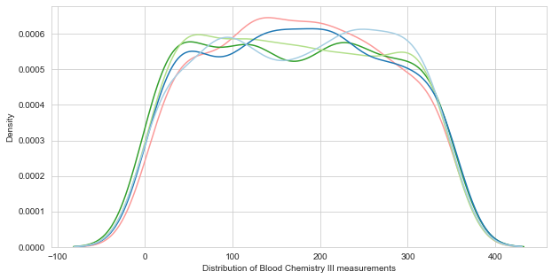

```python
fig, ax = plt.subplots(figsize=(10, 5))
ax = sns.kdeplot(data=original_df, x="blood_3", hue="measure_no")
ax.set(xlabel='Distribution of Blood Chemistry III measurements')
plt.legend([],[], frameon=False)
plt.show()
```

```python
df.groupby('outcome')[measure_no].median()
```

| measure_no outcome | blood_3_m_1 | blood_3_m_2 | blood_3_m_3 | blood_3_m_4 | blood_3_m_5 |
| --- | --- | --- | --- | --- | --- |
| No | 185.5 | 170.0 | 167.5 | 167.5 | 175.5 |
| Yes | 166.0 | 181.0 | 172.5 | 177.0 | 171.5 |

For better understanding of blood chemistry III variable, for every 5 measurements of each patient we calculted the mean, standard deviation, median and variance coefficient. Next, all computed metrics were plotted on the histograms to check if probability of being ill depend on the mean, median or degree of volatility of the blood III measurements. Because histograms for both sick and healthy patients look similar, one can infer that neither mean nor volatility of blood III samples affect the probability of positive diagnosis.

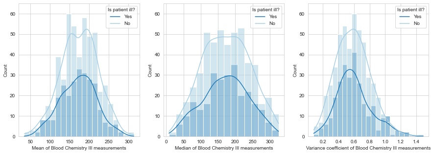

```python
blood_3_df = df[['id', 'outcome', *measure_no]].copy()
blood_3_df['median'] = blood_3_df[measure_no].median(axis=1)
blood_3_df['mean'] = blood_3_df[measure_no].mean(axis=1)
blood_3_df['sd'] = blood_3_df[measure_no].std(axis=1)
blood_3_df['cv'] = blood_3_df['sd'] / blood_3_df['mean']

fig, axs = plt.subplots(1, 3, figsize=(15, 5))
# Mean
sns.histplot(data=blood_3_df, x="mean", hue="outcome", kde=True, ax=axs[0])
axs[0].set(xlabel='Mean of Blood Chemistry III measurements', ylabel='Count')
axs[0].legend(title='Is patient ill?', loc='upper right', labels=['Yes', 'No'])
axs[0].set(ylim=(0, 65))
# Median
sns.histplot(data=blood_3_df, x="median", hue="outcome", kde=True, ax=axs[1])
axs[1].set(xlabel='Median of Blood Chemistry III measurements', ylabel='Count')
axs[1].legend(title='Is patient ill?', loc='upper right', labels=['Yes', 'No'])
axs[1].set(ylim=(0, 65))
# Variance coeff
sns.histplot(data=blood_3_df, x="cv", hue="outcome", kde=True, ax=axs[2])
axs[2].set(xlabel='Variance coefficient of Blood Chemistry III measurements', ylabel='Count')
axs[2].legend(title='Is patient ill?', loc='upper right', labels=['Yes', 'No'])
axs[2].set(ylim=(0, 65))
plt.show()
```

On the histograms below, one can notice that distribution of blood chemistry I and II for ill differs between ill and healthy patients. Individuals diagnosed as ill tend to have higher values of both blood components. Apart from that, almost 50% observations take 0 value for blood chemistry II. Because it is not possible to say with certainty whether 0 is a valid value in this column, it was decided to not treat those values as missing and keep them as they are. On the other hand, blood chemistry I also contains some 0-values which significantly differ from the remaining values. In this case, zero values are more likely to be considered as missing values.

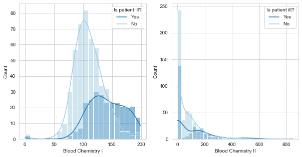

```python
fig, axs = plt.subplots(1, 2, figsize=(10, 5))
# Blood 1
sns.histplot(data=df, x="blood_1", hue="outcome", kde=True, ax=axs[0])
axs[0].set(xlabel='Blood Chemistry I', ylabel='Count')
axs[0].legend(title='Is patient ill?', loc='upper right', labels=['Yes', 'No'])
# Blood 2
sns.histplot(data=df, x="blood_2", hue="outcome", kde=True, ax=axs[1])
axs[1].set(xlabel='Blood Chemistry II', ylabel='Count')
axs[1].legend(title='Is patient ill?', loc='upper right', labels=['Yes', 'No'])
plt.show()
```

```python
df['blood_1'] = df['blood_1'].replace(0, np.NaN)
```

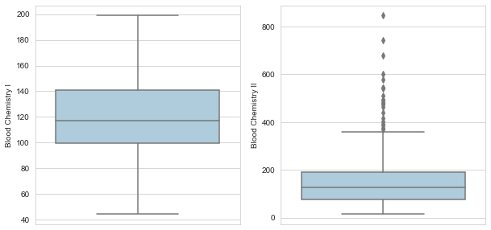

```python
fig, axs = plt.subplots(1, 2, figsize=(10, 5))
# Blood 1
sns.boxplot(data=df, y="blood_1", ax=axs[0])
axs[0].set(ylabel='Blood Chemistry I', xlabel='')
# Blood 2
sns.boxplot(data=df[df["blood_2"] != 0], y="blood_2", ax=axs[1])
axs[1].set(ylabel='Blood Chemistry II', xlabel='')
plt.show()
```

```python
df[df["blood_2"] > 600]
```

| measure_no | id | pregnancies | blood_1 | blood_2 | blood_pressure | skin_thickness | bmi | gen_pred_factor | age | air_quality | state | outcome | blood_3_m_1 | blood_3_m_2 | blood_3_m_3 | blood_3_m_4 | blood_3_m_5 |
| --- | --- | --- | --- | --- | --- | --- | --- | --- | --- | --- | --- | --- | --- | --- | --- | --- | --- |
| 481 | 5642599.0 | 0.0 | 165.0 | 680.0 | 90.0 | 33.0 | 52.3 | 0.427 | 23.0 | 19.0 | FL | No | 212.0 | 35.0 | 289.0 | 103.0 | 214.0 |
| 495 | 5642613.0 | 4.0 | 197.0 | 744.0 | 70.0 | 39.0 | 36.7 | 2.329 | 31.0 | 65.0 | NC | No | 330.0 | 297.0 | 108.0 | 131.0 | 47.0 |
| 752 | 5642870.0 | 1.0 | 189.0 | 846.0 | 60.0 | 23.0 | 30.1 | 0.398 | 59.0 | 27.0 | IL | Yes | 73.0 | 100.0 | 162.0 | 314.0 | 155.0 |

```python
df = df[df["blood_2"] <= 600]
```

### Blood preassure, skin thickness, BMI and age

The below boxplots display the distribution of the blood preassure, skin thickness, age and BMI. One can notice some extreme data eg. patient having 230 years or skin thicness having almost 100 units. These observations were removed from the dataset. Additionally, it is obvious that 0 is not valid value for features like blood preassure, skin thickness and BMI. For this reason such observations are treated as missing values.

```python
df['blood_pressure'] = df['blood_pressure'].replace(0, np.NaN)
df['skin_thickness'] = df['skin_thickness'].replace(0, np.NaN)
df['bmi'] = df['bmi'].replace(0, np.NaN)
```

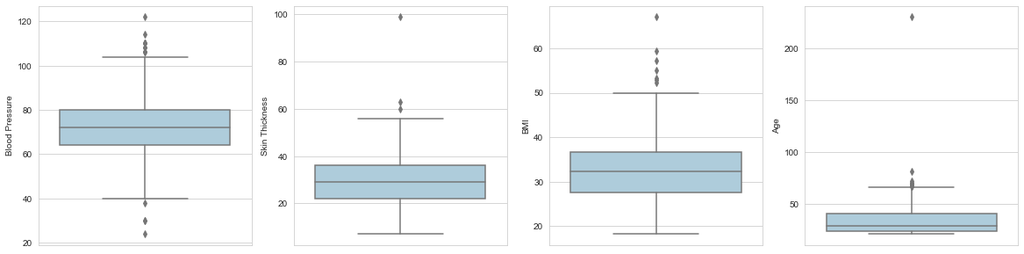

```python
fig, axs = plt.subplots(1, 4, figsize=(20, 5))
sns.boxplot(data=df, y="blood_pressure", ax=axs[0])
axs[0].set(ylabel='Blood Pressure', xlabel='')
sns.boxplot(data=df, y="skin_thickness", ax=axs[1])
axs[1].set(ylabel='Skin Thickness', xlabel='')
sns.boxplot(data=df, y="bmi", ax=axs[2])
axs[2].set(ylabel='BMI', xlabel='')
sns.boxplot(data=df, y="age", ax=axs[3])
axs[3].set(ylabel='Age', xlabel='')
plt.show()
```

```python
df[(df['blood_pressure'] < 35) | (df['blood_pressure'] > 110)]
```

| measure_no | id | pregnancies | blood_1 | blood_2 | blood_pressure | skin_thickness | bmi | gen_pred_factor | age | air_quality | state | outcome | blood_3_m_1 | blood_3_m_2 | blood_3_m_3 | blood_3_m_4 | blood_3_m_5 |
| --- | --- | --- | --- | --- | --- | --- | --- | --- | --- | --- | --- | --- | --- | --- | --- | --- | --- |
| 91 | 5642209.0 | 1.0 | 89.0 | 25.0 | 24.0 | 19.0 | 27.8 | 0.559 | 21.0 | 33.0 | CA | No | 199.0 | 37.0 | 0.0 | 273.0 | 261.0 |
| 148 | 5642266.0 | 1.0 | 96.0 | 0.0 | 122.0 | NaN | 22.4 | 0.207 | 27.0 | 54.0 | MN | No | 63.0 | 289.0 | 53.0 | 190.0 | 149.0 |
| 212 | 5642330.0 | 1.0 | 103.0 | 83.0 | 30.0 | 38.0 | 43.3 | 0.183 | 33.0 | 72.0 | OH | No | 181.0 | 280.0 | 244.0 | 106.0 | 200.0 |
| 506 | 5642624.0 | 1.0 | 88.0 | 99.0 | 30.0 | 42.0 | 55.0 | 0.496 | 26.0 | 67.0 | MA | Yes | 324.0 | 127.0 | 76.0 | 25.0 | 35.0 |
| 680 | 5642798.0 | 13.0 | 158.0 | 0.0 | 114.0 | NaN | 42.3 | 0.257 | 44.0 | 54.0 | TX | Yes | 190.0 | 233.0 | 257.0 | 39.0 | 224.0 |

```python
df = df[(df['blood_pressure'] > 35) & (df['blood_pressure'] < 110) | (df['blood_pressure'].isna())]
```

```python
df = df[(df['skin_thickness'] < 80) | (df['skin_thickness'].isna())]
```

```python
df = df[(df['bmi'] < 60) | (df['bmi'].isna())]
```

```python
df = df[(df['age'] < 80) | (df['age'].isna())]
```

```python
df.shape
```

```
(752, 17)
```

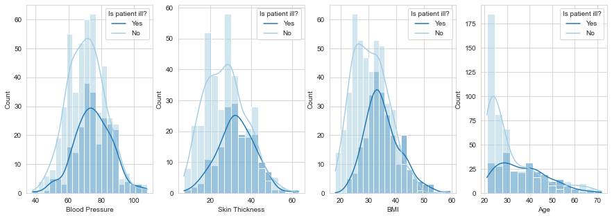

```python
fig, axs = plt.subplots(1, 4, figsize=(15, 5))
# Blood preassure
sns.histplot(data=df, x="blood_pressure", hue="outcome", kde=True, ax=axs[0])
axs[0].set(xlabel='Blood Pressure', ylabel='Count')
axs[0].legend(title='Is patient ill?', loc='upper right', labels=['Yes', 'No'])
# axs[0].set(ylim=(0, 65))
# Skin Thickness
sns.histplot(data=df, x="skin_thickness", hue="outcome", kde=True, ax=axs[1])
axs[1].set(xlabel='Skin Thickness', ylabel='Count')
axs[1].legend(title='Is patient ill?', loc='upper right', labels=['Yes', 'No'])
# axs[1].set(ylim=(0, 65))
# BMI
sns.histplot(data=df, x="bmi", hue="outcome", kde=True, ax=axs[2])
axs[2].set(xlabel='BMI', ylabel='Count')
axs[2].legend(title='Is patient ill?', loc='upper right', labels=['Yes', 'No'])
# Age
sns.histplot(data=df, x="age", hue="outcome", kde=True, ax=axs[3])
axs[3].set(xlabel='Age', ylabel='Count')
axs[3].legend(title='Is patient ill?', loc='upper right', labels=['Yes', 'No'])
plt.show()
```

The diagonal of the plot below consists of density plots of variables analysed in this section. The plots being outside the diagonal shows the relationship between each pair of values: blood preassure, skin thickness, age and BMI. Apparently, there is a positive, linear relationship between skin thickness and BMI of the patient. What is more, the plots provide some evidence that patients who have higher blood pressure, thicker skin or are overweight, are at higher risk of becoming ill. It is also noticable that the likelihood of getting the disease increases with age.

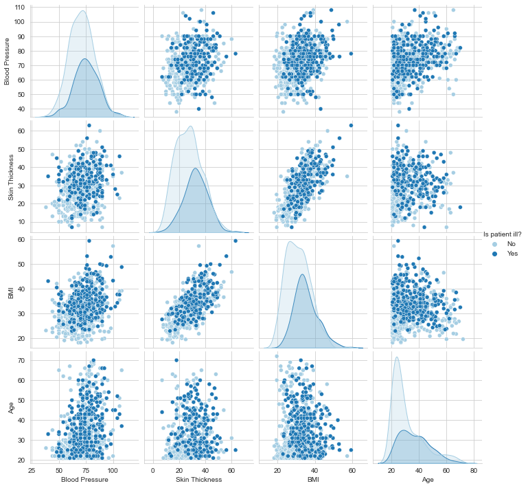

```python
labels=['Blood Pressure', 'Skin Thickness', 'BMI', 'Age']
plot_df = df[['blood_pressure', 'skin_thickness', 'bmi', 'age', 'outcome']].copy().rename(cols_dict, axis=1)
g = sns.pairplot(plot_df, hue='Outcome')
g._legend.set_title('Is patient ill?')
```

### Genetic predisposition factor

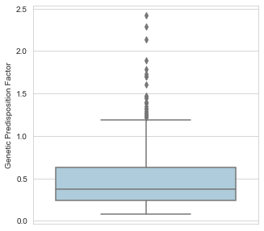

```python
fig, ax = plt.subplots(figsize=(5, 5))
sns.boxplot(data=df, y="gen_pred_factor")
ax.set(ylabel='Genetic Predisposition Factor', xlabel='')
plt.show()
```

```python
df[df['gen_pred_factor'] > 1.5].sort_values('gen_pred_factor', ascending=False)
```

| measure_no | id | pregnancies | blood_1 | blood_2 | blood_pressure | skin_thickness | bmi | gen_pred_factor | age | air_quality | state | outcome | blood_3_m_1 | blood_3_m_2 | blood_3_m_3 | blood_3_m_4 | blood_3_m_5 |
| --- | --- | --- | --- | --- | --- | --- | --- | --- | --- | --- | --- | --- | --- | --- | --- | --- | --- |
| 729 | 5642847.0 | 0.0 | 180.0 | 14.0 | 78.0 | 63.0 | 59.4 | 2.420 | 25.0 | 86.0 | IL | Yes | 82.0 | 221.0 | 199.0 | 339.0 | 293.0 |
| 626 | 5642744.0 | 0.0 | 137.0 | 168.0 | 40.0 | 35.0 | 43.1 | 2.288 | 33.0 | 11.0 | AZ | Yes | 149.0 | 236.0 | 50.0 | 259.0 | 325.0 |
| 714 | 5642832.0 | 3.0 | 173.0 | 465.0 | 82.0 | 48.0 | 38.4 | 2.137 | 25.0 | 89.0 | KS | Yes | 310.0 | 276.0 | 210.0 | 33.0 | 112.0 |
| 728 | 5642846.0 | 0.0 | 180.0 | 0.0 | 66.0 | 39.0 | 42.0 | 1.893 | 25.0 | 54.0 | GA | Yes | 189.0 | 302.0 | 60.0 | 110.0 | 155.0 |
| 453 | 5642571.0 | 0.0 | 146.0 | 0.0 | 82.0 | NaN | 40.5 | 1.781 | 44.0 | 2.0 | WA | No | 140.0 | 277.0 | 213.0 | 323.0 | 241.0 |
| 325 | 5642443.0 | 0.0 | 118.0 | 89.0 | 64.0 | 23.0 | NaN | 1.731 | 21.0 | 12.0 | AL | No | 312.0 | 139.0 | 293.0 | 12.0 | 268.0 |
| 50 | 5642168.0 | 2.0 | 82.0 | 115.0 | 52.0 | 22.0 | 28.5 | 1.699 | 25.0 | 10.0 | LA | No | 116.0 | 332.0 | 298.0 | 147.0 | 72.0 |
| 117 | 5642235.0 | 2.0 | 92.0 | 0.0 | 76.0 | 20.0 | 24.2 | 1.698 | 28.0 | 88.0 | NJ | No | 42.0 | 162.0 | 163.0 | 200.0 | 280.0 |
| 385 | 5642503.0 | 2.0 | 127.0 | 275.0 | 58.0 | 24.0 | 27.7 | 1.600 | 25.0 | 24.0 | LA | No | 270.0 | 30.0 | 343.0 | 184.0 | 313.0 |

### State and air quality

The dataset contains ifnormation about the state where each individual lives. The table below shows which state characterizes proportion of positively diagnosed patients higher than the proportion in the whole population. These states includes Arkansas, Florida, California and Alabama.

```python
state_df = df.groupby('state')['outcome'].value_counts(normalize=True)
state_df.index.names = ["state", "illness"]
state_df = state_df.reset_index()
state_df[(state_df['outcome'] > 0.35) & (state_df['illness'] == 'Yes')]
```

|  | state | illness | outcome |
| --- | --- | --- | --- |
| 1 | AL | Yes | 0.384615 |
| 3 | AR | Yes | 0.375000 |
| 7 | CA | Yes | 0.359223 |
| 14 | FL | Yes | 0.370370 |
| 27 | KU | Yes | 1.000000 |
| 38 | MI | Yes | 0.370370 |
| 44 | MS | Yes | 0.428571 |
| 47 | NC | Yes | 0.384615 |
| 68 | SC | Yes | 0.384615 |
| 71 | TN | Yes | 0.388889 |
| 72 | TX | Yes | 0.960000 |
| 84 | WV | Yes | 0.400000 |

To not include to many categorical variables in the model, every state was assigned to its corresponding region: South, West, Midwest or Northeast. One state named KU, which doesn't match any state in the mapping, was replaced by the most frequent value. Apparently, patients who live in the southern part of the USA are more likely to get ill. At the same time, the bad air quality of the patient's hometown doesn't increase the risk of getting ill.

```python
# Replace each state by its corresponding region
usa = pd.read_csv('usa_states.csv')
usa.columns = ["state_name", "state", "region", 'division']
df = pd.merge(left=df, right=usa[['state', 'region']], how='left', left_on='state', right_on='state')
```

```python
# Revert mapping of Y variable
df["outcome"] = df["outcome"].map({"Yes": 1, "No": 0})

# Show the portion of ill patients in each region
region_cnt = df['region'].value_counts()
df.groupby('region')['outcome'].agg('mean').sort_values(ascending=False)
```

```
region
South        0.409774
Midwest      0.315476
West         0.311111
Northeast    0.301471
Name: outcome, dtype: float64
```

```python
# Replace mysterious state with with the most frequent value
df['region'] = np.where(df['region'].isna(), region_cnt.index[0], df['region'])
```

```python
df.shape
```

```
(752, 18)
```

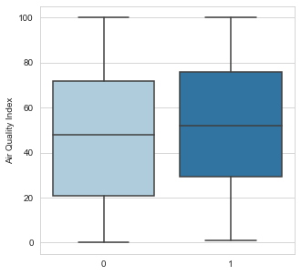

```python
fig, ax = plt.subplots(figsize=(5, 5))
sns.boxplot(data=df, y="air_quality", x='outcome')
ax.set(ylabel='Air Quality Index', xlabel='')
plt.show()
```

## Correlation

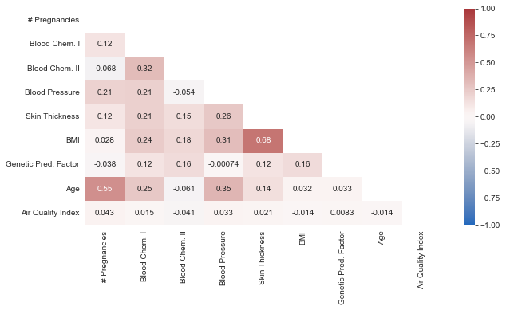

```python
df_corr = df[['pregnancies', 'blood_1', 'blood_2', 'blood_pressure',
              'skin_thickness', 'bmi', 'gen_pred_factor', 'age', 'air_quality']].copy().rename(cols_dict, axis=1)

plt.figure(figsize=(10, 5))
# define the mask to set values in the upper part to True
mask = np.triu(np.ones_like(df_corr.corr(), dtype=np.bool))
heatmap = sns.heatmap(df_corr.corr(), mask=mask, vmin=-1, vmax=1, annot=True, cmap='vlag')
```

## Train-test split

Before building the classifier, the data were split into train and test sets. The train set consists of 652 observations, while test set, which is use to estimate the performance of model, has 100 observations. After splitting, both sets were compared in terms of basic descriptive statistics, which turned out to be very similar.

```python
from sklearn.model_selection import train_test_split
from sklearn.preprocessing import LabelBinarizer
from sklearn.impute import KNNImputer
from sklearn.feature_selection import mutual_info_classif as MI
from sklearn.model_selection import RandomizedSearchCV
from sklearn.ensemble import RandomForestClassifier
from sklearn.metrics import accuracy_score, confusion_matrix, roc_curve, auc, roc_auc_score, precision_score, recall_score, f1_score
from sklearn.tree import plot_tree
from sklearn.inspection import permutation_importance
from sklearn.inspection import PartialDependenceDisplay, partial_dependence
```

```python
seed = 61
```

```python
# Dataset with pre-selected columns
model_cols = ['pregnancies', 'blood_1', 'blood_2', 'blood_pressure',
              'skin_thickness', 'bmi', 'gen_pred_factor', 'age',
              'air_quality', 'region', 'outcome']
df_model = df[model_cols].copy()
df_model.reset_index(inplace=True, drop=True)
model_cols.remove('outcome')

# Split into train and test set
y, X = df_model['outcome'], df_model[model_cols]
X_train, X_test, y_train, y_test = train_test_split(X, y, test_size=100, random_state=seed)
X_train.shape, y_train.shape, X_test.shape, y_test.shape
```

```
((652, 10), (652,), (100, 10), (100,))
```

```python
round(X_train.describe().T, 3)
```

|  | count | mean | std | min | 25% | 50% | 75% | max |
| --- | --- | --- | --- | --- | --- | --- | --- | --- |
| pregnancies | 652.0 | 3.873 | 3.356 | 0.000 | 1.00 | 3.000 | 6.000 | 17.000 |
| blood_1 | 648.0 | 121.256 | 29.725 | 44.000 | 100.00 | 117.000 | 140.000 | 199.000 |
| blood_2 | 652.0 | 77.423 | 106.766 | 0.000 | 0.00 | 23.000 | 129.250 | 579.000 |
| blood_pressure | 625.0 | 72.370 | 11.489 | 38.000 | 64.00 | 72.000 | 80.000 | 108.000 |
| skin_thickness | 453.0 | 29.000 | 10.053 | 7.000 | 21.00 | 29.000 | 36.000 | 60.000 |
| bmi | 642.0 | 32.582 | 6.627 | 18.200 | 27.60 | 32.400 | 36.600 | 57.300 |
| gen_pred_factor | 652.0 | 0.461 | 0.313 | 0.078 | 0.24 | 0.366 | 0.605 | 2.288 |
| age | 652.0 | 33.075 | 11.468 | 21.000 | 24.00 | 29.000 | 40.000 | 70.000 |
| air_quality | 649.0 | 48.524 | 29.297 | 0.000 | 23.00 | 48.000 | 72.000 | 100.000 |

```python
round(X_test.describe().T, 3)
```

|  | count | mean | std | min | 25% | 50% | 75% | max |
| --- | --- | --- | --- | --- | --- | --- | --- | --- |
| pregnancies | 100.0 | 3.680 | 3.336 | 0.0 | 1.000 | 3.000 | 6.00 | 15.00 |
| blood_1 | 96.0 | 121.708 | 33.513 | 56.0 | 95.000 | 119.000 | 145.00 | 195.00 |
| blood_2 | 100.0 | 76.730 | 114.809 | 0.0 | 0.000 | 28.500 | 111.25 | 600.00 |
| blood_pressure | 92.0 | 71.957 | 12.806 | 48.0 | 63.500 | 71.000 | 80.50 | 104.00 |
| skin_thickness | 73.0 | 29.041 | 10.265 | 7.0 | 23.000 | 28.000 | 35.00 | 63.00 |
| bmi | 99.0 | 30.808 | 7.070 | 19.5 | 25.050 | 30.400 | 35.35 | 59.40 |
| gen_pred_factor | 100.0 | 0.531 | 0.405 | 0.1 | 0.248 | 0.396 | 0.74 | 2.42 |
| age | 100.0 | 33.420 | 12.406 | 21.0 | 24.000 | 29.000 | 41.00 | 72.00 |
| air_quality | 98.0 | 52.704 | 29.134 | 0.0 | 28.500 | 55.500 | 77.75 | 100.00 |

```python
X_train.reset_index(inplace=True, drop=True)
X_test.reset_index(inplace=True, drop=True)
```

## k-NN Imputation for missing values

Because missing data may reduce the predictive ability of the ML model and decrease the representativeness of the observations, in the following report they were imputed with use of k-NN Imputation technique. k-NN Imputer is looking for k nearest observations lying in the neighborhood of point with missing attribute and replace it with the mean value of its nearest neighbors. The choose of k parameter was made with taking into consideration the fact that k should be an odd number, not too big to not overfit the model and not to big to not get too much generalized predictions. Because algorithm uses distance metric, it is sensitive to features' scale. For that reason, before applying k-NN imputation, the data were scaled. Additionally, categorical variable region was replaced by numeric value indicating fraction of ill patients living in such location. Each method was conducted separately on the train and test set to prevent information leakage.

```python
X_train.isna().sum()
```

```
pregnancies          0
blood_1              4
blood_2              0
blood_pressure      27
skin_thickness     199
bmi                 10
gen_pred_factor      0
age                  0
air_quality          3
region               0
dtype: int64
```

```python
X_test.isna().sum()
```

```
pregnancies         0
blood_1             4
blood_2             0
blood_pressure      8
skin_thickness     27
bmi                 1
gen_pred_factor     0
age                 0
air_quality         2
region              0
dtype: int64
```

```python
# # One-hot encoding
# # Transform categorical variable 'region' into four binary columns
# label_bin = LabelBinarizer()
# label_bin_output = pd.DataFrame(label_bin.fit_transform(X_train['region']), columns=label_bin.classes_)
# X_train_knn = pd.concat([X_train, label_bin_output], axis=1)
# label_bin_output = pd.DataFrame(label_bin.fit_transform(X_test['region']), columns=label_bin.classes_)
# X_test_knn = pd.concat([X_test, label_bin_output], axis=1)

# # Drop 'region' and 'West' columns to avoid data redundancy
# X_train_knn.drop(columns=['region', 'West'], inplace=True)
# X_test_knn.drop(columns=['region', 'West'], inplace=True)
```

```python
# Concat X and y to calculate fraction of ill patients for each region
df_train = pd.concat([X_train.reset_index(), y_train.reset_index()], axis=1)
df_test = pd.concat([X_test.reset_index(), y_test.reset_index()], axis=1)
```

```python
# Target Encoding
encodings_train = df_train.groupby('region')['outcome'].mean().reset_index()
X_train_knn = X_train.merge(encodings_train, how='left', on='region')
X_train_knn.drop(columns=['region'], axis=1, inplace=True)
X_train_knn.rename({'outcome': 'region_prob'}, axis=1, inplace=True)

encodings_test = df_test.groupby('region')['outcome'].mean().reset_index()
X_test_knn = X_test.merge(encodings_test, how='left', on='region')
X_test_knn.drop(columns=['region'], axis=1, inplace=True)
X_test_knn.rename({'outcome': 'region_prob'}, axis=1, inplace=True)
```

```python
# Scale data
X_train_knn_scaled = (X_train_knn - X_train_knn.mean()) / X_train_knn.std()
X_test_knnn_scaled = (X_test_knn - X_test_knn.mean()) / X_test_knn.std()
```

```python
# Apply k-NN imputer and replace missing data
imputer = KNNImputer(n_neighbors=7)
X_train_knn_scaled = pd.DataFrame(imputer.fit_transform(X_train_knn_scaled), columns=X_train_knn_scaled.columns)
X_test_knn_scaled = pd.DataFrame(imputer.fit_transform(X_test_knnn_scaled), columns=X_test_knnn_scaled.columns)
X_train_knn_scaled.shape, X_test_knn_scaled.shape
```

```
((652, 10), (100, 10))
```

```python
X_train_knn_scaled.isna().sum().sum(), X_test_knn_scaled.isna().sum().sum()
```

```
(0, 0)
```

```python
# Scale data back
X_train_after_knn = ((X_train_knn_scaled * X_train_knn.std()) + X_train_knn.mean())
X_test_after_knn = ((X_test_knn_scaled * X_test_knn.std()) + X_test_knn.mean())
```

One can notice that after imputing missing values, the histogram of skin thickness become more smooth. The reason is that the means calculated by imputer are taken from k=7 nearest neighbors which most probably take value closer to the center of the distribution than to its tails.

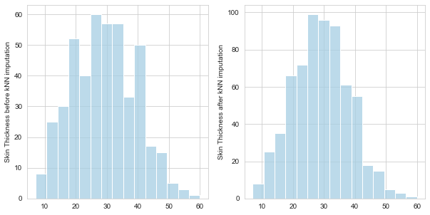

```python
# Compare variable histograms before and after filling missing values
fig, axs = plt.subplots(1, 2, figsize=(10, 5))
sns.histplot(data=X_train, x="skin_thickness", fill=True, legend=False, ax=axs[0], bins=15)
axs[0].set(ylabel='Skin Thickness before kNN imputation', xlabel='')
sns.histplot(data=X_train_after_knn, x="skin_thickness", fill=True, legend=False, ax=axs[1], bins=15)
axs[1].set(ylabel='Skin Thickness after kNN imputation', xlabel='')
plt.show()
```

## Feature selection with Mutual Information Classifier

Before training the model, the least relevant features were removed from the X set based on Mutual Information metric. It measures the dependence between two variables, so, in other words, the extent to which the values of one variable explain the values of another variable. It can be seen at the plot of features importance below, that variables with the highest predictive power of the patient's illness are blood component I and BMI. Some information gain about patient health is also obtained with the results about their blood chemistry II and skin thickness. Almost no information gain is given by data about patient living region and its air quality. Finally, to build the model, it was decided to use all variables except region and air quality.

```python
mutual_info = MI(X_train_after_knn, y_train, random_state=seed)
mutual_info = pd.Series(mutual_info)
mutual_info.index = X_train_after_knn.columns
mutual_info.sort_values(ascending=False)
```

```
blood_1            0.117334
bmi                0.087361
blood_2            0.041981
skin_thickness     0.038681
pregnancies        0.034338
blood_pressure     0.032893
age                0.025870
gen_pred_factor    0.016776
region_prob        0.005022
air_quality        0.000000
dtype: float64
```

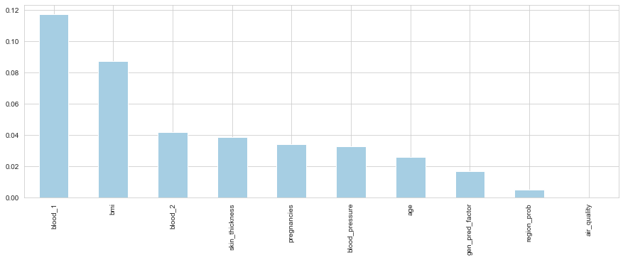

```python
mutual_info.sort_values(ascending=False).plot.bar(figsize=(15, 5))
plt.show()
```

```python
# Keep only features with MI > threshold
threshold = 0.01
selected_col = list(mutual_info[mutual_info > threshold].index)
X_test = X_test_after_knn[selected_col]
X_train = X_train_after_knn[selected_col]
```

## Random Forest classifier

The model built to help doctors in diagnosing patients is random forest classifier. The model uses multiple decision trees and make a decision on the basis of majority vote. When constructing each node of decision tree, only a small part of all features is considered. It prevents model from using the same, strongest predictors when building the trees. As a result many uncorrelated decision trees are created which predictions are avaraged to obtain a final classification decision.

Before training the model, hyperparameter tuning was conducted to select the combination of model parameters giving the lowest cross-validation test error rate. It was done with use of randomized search, which search through random values selected from the parameter space we define. The method indicated a set of following optimal hyperparameters:

- number of trees in the forest: 200
- method of calculating maximum number of features to consider at each split: square root of total number of features
- maximum depth of tree: 4 levels
- minimum samples present in the leaf node: 11
- minimum number of observations to split the node: 30

### Hyperparameter tuning

```python
# Number of trees in random forest
n_estimators = [int(x) for x in np.linspace(50, 300, 6, endpoint=True)]
# Number of features to consider at every split
max_features = ['auto', 'sqrt']
# Max number of levels in tree
max_depth = [int(x) for x in np.linspace(1, 4, 3, endpoint=True)]
# Min number of observations allowed in a leaf node
min_samples_leaf = [int(x) for x in np.linspace(1, 11, 5, endpoint=True)]
# Min number of observations in a node before splitting the node
min_samples_split = [int(x) for x in np.linspace(5, 55, 5, endpoint=True)]

random_grid = {'n_estimators': n_estimators,
                'max_features': max_features,
                'max_depth': max_depth,
                'min_samples_leaf': min_samples_leaf,
                'min_samples_split': min_samples_split}
```

```python
forest = RandomForestClassifier(random_state=seed)

rf_cv = RandomizedSearchCV(estimator = forest,
                           param_distributions = random_grid,
                           n_iter = 20, cv=5, verbose=2,
                           random_state=seed, n_jobs = -1)
rf_cv.fit(X_train, y_train)
rf_cv.best_params_
```

```
Fitting 5 folds for each of 20 candidates, totalling 100 fits
```

```
{'n_estimators': 200,
 'min_samples_split': 30,
 'min_samples_leaf': 11,
 'max_features': 'sqrt',
 'max_depth': 4}
```

### Fitting the model

The random forest classifier was fit on the parameters found from the random search. The train accuracy of the model is 0.799 what means that 79.9% patient from the trainset were correctly classified. The test accuracy is higher and equals 0.87 which can be interpreted the same way - 87% patients from the test set were correctly diagnosed by the model. The AUC score which provides an aggregate measure of model performance across all possible thresholds of classification equals 81.9%.

```python
rf = RandomForestClassifier(n_estimators=rf_cv.best_params_['n_estimators'],
                            min_samples_split=rf_cv.best_params_['min_samples_split'],
                            min_samples_leaf=rf_cv.best_params_['min_samples_leaf'],
                            max_features=rf_cv.best_params_['max_features'],
                            max_depth=rf_cv.best_params_['max_depth'], random_state=seed)
rf.fit(X_train, y_train)
```

```
RandomForestClassifier(max_depth=4, max_features='sqrt', min_samples_leaf=11,
                       min_samples_split=30, n_estimators=200, random_state=61)
```

```python
y_train_pred = rf.predict(X_train)
y_pred = rf.predict(X_test)
```

```python
train_acc = accuracy_score(y_train, y_train_pred)
test_acc = accuracy_score(y_test, y_pred)
false_positive_rate, true_positive_rate, thresholds = roc_curve(y_test, y_pred)

print(f'Train accuracy = {round(train_acc, 3)}\n',
      f'Test accuracy = {round(test_acc, 3)}\n',
      f'AUC = {round(auc(false_positive_rate, true_positive_rate), 3)}', sep="")
```

```
Train accuracy = 0.799
Test accuracy = 0.87
AUC = 0.819
```

### Confusion matrix

A confusion matrix gives a picture of classification model performance and the types of errors it produced. The trained random forest classifier having a threshold of classification set to 0.5 gives precision equal to 100%, recall equal to 63.9% and specificity equal to 100%. It means that 100% of patients thought by the classifier to have the disease, actually have the disease. Value of recall (and sensitivity) says that out off all people that have the disease, only 63.9% got positive diagnose. Specificity indicates that 100% of healthy patients were classified to the correct class. The F1 score which measures both the precision and recall equals 78%.

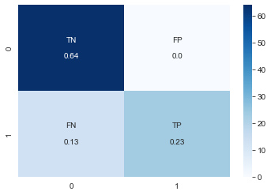

```python
cf_matrix = confusion_matrix(y_test, y_pred)
group_names = ['TN','FP','FN','TP']
group_counts = [round(value, 3) for value in cf_matrix.flatten()/cf_matrix.sum()]
labels = [f'{v1}\n\n{v2}' for v1, v2 in zip(group_names, group_counts)]
labels = np.asarray(labels).reshape(2, 2)
sns.heatmap(cf_matrix, annot=labels, fmt='', cmap='Blues')
plt.show()
```

```python
tn, fp, fn, tp = cf_matrix.ravel()
specificity = tn / (tn+fp)
sensitivity = tp / (tp+fn)
print(f'Precision = {round(precision_score(y_test, y_pred), 3)}\n',
      f'Recall = {round(recall_score(y_test, y_pred), 3)}\n',
      f'Specificity = {round(specificity, 3)}\n',
      f'Sensitivity  = {round(sensitivity, 3)}\n',
      f'F1_score = {round(f1_score(y_test, y_pred), 3)}', sep="")
```

```
Precision = 1.0
Recall = 0.639
Specificity = 1.0
Sensitivity  = 0.639
F1_score = 0.78
```

#### Adjusting classification threshold

In the medical industry, it is common to look for specificity and recall (sensitivity) to evaluate the model performance. Sensitivity is a measure of how well the classifier detects cases of people that have a disease. If recall=1, that means that all patients with the disease are classified correctly. Another important metric is specificity which says how many negative model predictions are actually negative.

```python
threshold = 0.35
predicted_proba = rf.predict_proba(X_test)
y_pred_adj = (predicted_proba[:,1] >= threshold).astype('int')
```

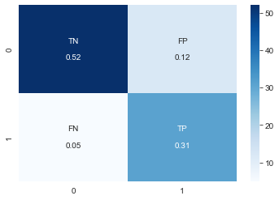

```python
cf_matrix = confusion_matrix(y_test, y_pred_adj)
tn, fp, fn, tp = cf_matrix.ravel()
group_counts_adj = [round(value, 3) for value in cf_matrix.flatten()/cf_matrix.sum()]
labels = [f'{v1}\n\n{v2}' for v1, v2 in zip(group_names, group_counts_adj)]
labels = np.asarray(labels).reshape(2, 2)
sns.heatmap(cf_matrix, annot=labels, fmt='', cmap='Blues')
plt.show()
```

```python
tn, fp, fn, tp = cf_matrix.ravel()
specificity = tn / (tn+fp)
sensitivity = tp / (tp+fn)
print(f'Accuracy = {round(accuracy_score(y_test, y_pred_adj), 3)}\n',
      f'Precision = {round(precision_score(y_test, y_pred_adj), 3)}\n',
      f'Recall = {round(recall_score(y_test, y_pred_adj), 3)}\n',
      f'Specificity = {round(specificity, 3)}\n',
      f'Sensitivity  = {round(sensitivity, 3)}\n',
      f'F1_score = {round(f1_score(y_test, y_pred_adj), 3)}', sep="")
```

```
Accuracy = 0.83
Precision = 0.721
Recall = 0.861
Specificity = 0.812
Sensitivity  = 0.861
F1_score = 0.785
```

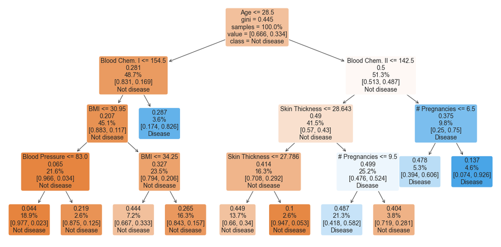

```python
plot_X_test = X_test.rename(cols_dict, axis=1)

tree = rf.estimators_[0]
plt.figure(figsize=(20, 10))
plot_tree(tree,
          feature_names=plot_X_test.columns,
          class_names = ['Not disease','Disease'],
          filled=True,
          rounded=True,
          fontsize=14,
          proportion = True,
          label='root')
plt.show()
```

Another insight we can gain from a random forest is to check what features turned out to be the most important in determining the patient diagnosis. We can see that blood chemistry I, BMI, age and skin thickness highly contribute to the model prediction of patient illness.

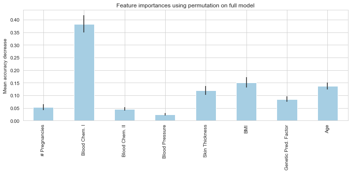

```python
feature_names = [f"{i}" for i in range(plot_X_test.shape[1])]
importances = rf.feature_importances_


forest_importances = pd.Series(importances, index=plot_X_test.columns)
result = permutation_importance(rf, plot_X_test, y_test, n_repeats=10, random_state=seed)
rf_importances = pd.Series(result.importances_mean, index=feature_names)
fig, ax = plt.subplots(figsize=(10, 5))
forest_importances.plot.bar(yerr=result.importances_std, ax=ax)
ax.set_title("Feature importances using permutation on full model")
ax.set_ylabel("Mean accuracy decrease")
fig.tight_layout()
plt.show()
```

```python
plot_X_test = X_test.rename(cols_dict, axis=1)
```

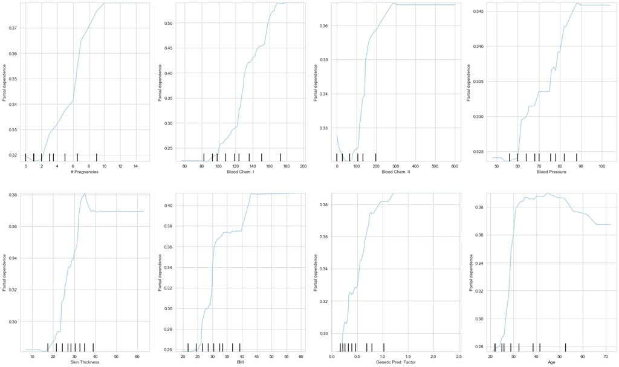

```python
fig, axs = plt.subplots(2, 4, figsize=(25, 15))
j=0
for i, col in enumerate(plot_X_test.columns):
    if i > 3:
        j=1; i=i-4
    PartialDependenceDisplay.from_estimator(rf, plot_X_test, [col], kind='average', ax=axs[j, i])
```

## Conclusion

The accuracy, recall and specificity of the model are to low to trust the classifier decisions without any doubt. On the other hand, the model can still be an important tool, helping doctors faster detect patients at higher risk of having disease, if used under the supervision of an expert in the specific medical field. What is more, it helped to identify the most important biological charasterictics of patients that affect their probability of illness. Finally, the model can be improved in the future by training on a larger dataset and performing more comprehensive hyperparameter tunning with use of wider parameter space.